```python
import pandas as pd
import numpy as np
import matplotlib.pyplot as plt
import datetime
import requests
from bs4 import BeautifulSoup
import time
import sys
import warnings; warnings.simplefilter('ignore')       # Ignore Warning
from sklearn.ensemble import RandomForestClassifier
from sklearn.linear_model.logistic import LogisticRegression
from sklearn.svm import LinearSVC
# make sure you have installed the following two packages:
import talib
import pandas_datareader.data as web
```

```python
def view_perc_bar(num,total,start):
    rate,time_passed = (num/total),(time.time()-start);num = int(rate * 50)
    r = '\r[%s%s]%d%%   %.1fs' % ("="*num, " "*(50-num),rate*100,time_passed )
    sys.stdout.write(r);sys.stdout.flush()
```

# I. Get Original Market Data(mktdata)

```python
# Original data is in txt format and we can easily read it using pa.read_csv('USDJPY.txt').
# But because original file is too big(about 200MB) to upload to Moodle, we save it to a HDF5 file "data.h5".
mktdata = pd.read_hdf('data.h5',key='USDJPY')
print('This is the original data! Shape = {}'.format(mktdata.shape))
mktdata.head()
```

```
This is the original data! Shape = (3897389, 8)
```

|  | <TICKER> | <DTYYYYMMDD> | <TIME> | <OPEN> | <HIGH> | <LOW> | <CLOSE> | <VOL> |
| --- | --- | --- | --- | --- | --- | --- | --- | --- |
| 0 | USDJPY | 20070101 | 220100 | 119.02 | 119.02 | 119.02 | 119.02 | 4 |
| 1 | USDJPY | 20070101 | 220200 | 119.02 | 119.02 | 119.02 | 119.02 | 4 |
| 2 | USDJPY | 20070101 | 220300 | 119.02 | 119.02 | 119.02 | 119.02 | 4 |
| 3 | USDJPY | 20070101 | 220400 | 119.02 | 119.03 | 119.02 | 119.03 | 4 |
| 4 | USDJPY | 20070101 | 220500 | 119.03 | 119.03 | 119.03 | 119.03 | 4 |

### Cut the mktdata from the beginning (to closest Sunday) and the ending(to closest Friday), because we will begin adding missing data for each WEEK later.

```python
def origin_data_clean(in_data,years=10):
    data = in_data.copy()
    print('start origin data cleaning! It will take around 5 minutes.')
    data.columns = ['symbol','date','time','open','high','low','close','vol']
    del data['vol']
    data['time'] = data['time'].apply(lambda x:str(x).zfill(6)[:-2])
    data['datetime'] = [datetime.datetime.strptime(str(x)+y,'%Y%m%d%H%M') for x,y in zip(data['date'],data['time'])]
    data['wkd'] = data['datetime'].apply(lambda x:x.weekday()+1)
    begind = data['date'].tolist()[-1] - years * 10000
    data = data[data['date']>=begind].sort_values('datetime')
    first_wkd7 = data[data['wkd']==7]['date'].tolist()[0]
    data = data[data['date']>=first_wkd7].reset_index(drop=True)
    last_wkd5 = data[data['wkd']==5]['date'].tolist()[-1]
    data = data[data['date']<=last_wkd5].reset_index(drop=True)
    data['date'] = data['date'].apply(lambda x:str(x))
    data['day'] = data['date'].apply(lambda x:x[-2:])
    data['month'] = data['date'].apply(lambda x:x[-4:-2])
    data['hour'] = data['time'].apply(lambda x:x[:2])
    data['minute'] = data['time'].apply(lambda x:x[2:])
    weeks = get_weeks(data['date'].tolist())
    print('origin data cleaning finished! Shape = {}'.format(data.shape))
    return data,weeks
def get_weeks(days):
    first_d1 = datetime.datetime.strptime(str(days[0]),'%Y%m%d')
    last_d6 = datetime.datetime.strptime(str(days[-1]),'%Y%m%d')
    first_d6 = first_d1+datetime.timedelta(days=5)
    now_week = (first_d1,first_d6)
    weeks = []
    while now_week[-1]<=last_d6:
        weeks.append(now_week)
        now_week = (now_week[0]+datetime.timedelta(days=7),now_week[1]+datetime.timedelta(days=7))
    weeks = [(str(x).replace('-','')[:8],str(y).replace('-','')[:8]) for x,y in weeks]
    return weeks
```

```python
clean_mktdata,weeks = origin_data_clean(mktdata,years=10)
clean_mktdata.head()
```

```
start origin data cleaning! It will take around 5 minutes.
origin data cleaning finished! Shape = (3645085, 13)
```

|  | symbol | date | time | open | high | low | close | datetime | wkd | day | month | hour | minute |
| --- | --- | --- | --- | --- | --- | --- | --- | --- | --- | --- | --- | --- | --- |
| 0 | USDJPY | 20070902 | 2200 | 115.75 | 115.75 | 115.75 | 115.75 | 2007-09-02 22:00:00 | 7 | 02 | 09 | 22 | 00 |
| 1 | USDJPY | 20070902 | 2201 | 115.75 | 115.75 | 115.75 | 115.75 | 2007-09-02 22:01:00 | 7 | 02 | 09 | 22 | 01 |
| 2 | USDJPY | 20070902 | 2202 | 115.75 | 115.75 | 115.75 | 115.75 | 2007-09-02 22:02:00 | 7 | 02 | 09 | 22 | 02 |
| 3 | USDJPY | 20070902 | 2203 | 115.75 | 115.75 | 115.75 | 115.75 | 2007-09-02 22:03:00 | 7 | 02 | 09 | 22 | 03 |
| 4 | USDJPY | 20070902 | 2204 | 115.76 | 115.84 | 115.76 | 115.82 | 2007-09-02 22:04:00 | 7 | 02 | 09 | 22 | 04 |

### 2. Add every missing minute in the middle (we add regardless of any market closing. We think this kind of adding way is appropriate because Forex Market is a global, 24hr market, so when any country has its own holiday and close the market, other countries' markets are still opening because they don't have the same holiday.

### Then the mktdata will become complete

```python
def add_lacked_data(input_df):
    df = input_df.copy()
    df.sort_values('datetime',inplace=True);df.drop_duplicates(inplace=True);df.reset_index(drop=True,inplace=True)
    datetimes = df['datetime'].tolist();cols = df.columns
    first_time,last_time = datetimes[0],datetimes[-1]
    #cut/add beginning
    if first_time.minute not in [0,30]:
        nums = first_time.minute
        if nums==0:
            df = df.drop(df.index.tolist()[0])
        elif 1<=nums<=15: #minute<15，to 0
            example = df.iloc[0].tolist()
            to_append = [example.copy() for i in range(nums)]
            for i in range(nums):
                to_append[i][7] = first_time - datetime.timedelta(minutes=i+1)
            df = df.append(pd.DataFrame(to_append,columns=cols))
        elif 15<nums<30:#minute in(16,29)，add to 30
            target_datetime = datetime.datetime(first_time.year,first_time.month,first_time.day,first_time.hour,30,0)
            temp = df[(df['datetime']>=first_time)&(df['datetime']<target_datetime)]
            if len(temp)>0:
                df = df.drop(temp.index.tolist())
        elif 30<nums<=45: #缺minute in (30,45)，to 30
            example = df.iloc[0].tolist()
            to_append = [example.copy() for i in range(nums-30)]
            for i in range(nums-30):
                to_append[i][7] = first_time - datetime.timedelta(minutes=i+1) #datetime
                open_price = example[3]
                to_append[i][4],to_append[i][5],to_append[i][6] = open_price,open_price,open_price
            df = df.append(pd.DataFrame(to_append,columns=cols))
        else: #minute in (45,59]，to 0 of next minute
            target_datetime = first_time + datetime.timedelta(minutes = 60-nums)
            temp = df[(df['datetime']>=first_time)&(df['datetime']<target_datetime)]
            if len(temp)>0:
                df = df.drop(temp.index.tolist())
    df.sort_values('datetime',inplace=True);df.reset_index(drop=True,inplace=True)
    #cut/add ending
    if last_time.minute not in [29,59]:
        nums = last_time.minute
        if nums<29: #minute in （0，28],to last minute's 59
            target_datetime = last_time - datetime.timedelta(minutes = nums+1)
            temp = df[(df['datetime']>target_datetime)&(df['datetime']<=last_time)]
            if len(temp)>0:
                df = df.drop(temp.index.tolist())
        elif 29<nums<59: # minute in [30-58]，to 29
            target_datetime = datetime.datetime(last_time.year,last_time.month,last_time.day,last_time.hour,29,0)
            temp = df[(df['datetime']>target_datetime)&(df['datetime']<=last_time)]
            if len(temp)>0:
                df = df.drop(temp.index.tolist())
    # resort datetime,reset_index,then add missing data in the middle
    df.reset_index(drop=True,inplace=True)
    datetimes = df['datetime'].tolist()
    lack_bars = ((datetimes[-1] - datetimes[0]).days*24*60 +(datetimes[-1] - datetimes[0]).seconds/60)+1 - len(df)
    if lack_bars>0: # Lack data in the middle
        for ii,t1,t2 in zip(df.index[1:],datetimes[:-1],datetimes[1:]):
            diff_min = (t2-t1).seconds/60
            if diff_min>1:
                nums = int(diff_min) -1
                example = df.iloc[ii].tolist()
                to_append = [example.copy() for i in range(nums)]
                for i in range(nums):
                    to_append[i][7] = example[7] - datetime.timedelta(minutes=i+1)
                    open_price = example[3]
                    to_append[i][4],to_append[i][5],to_append[i][6] = open_price,open_price,open_price
                df = df.append(pd.DataFrame(to_append,columns=cols))
                lack_bars-=nums
                if lack_bars==0:
                    break
    df.sort_values('datetime',inplace=True);df.reset_index(drop=True,inplace=True)
    # remake columns of "date" and "time"
    df['date'] = df['datetime'].apply(lambda x:str(x)[:10].replace('-',''))
    df['time'] = df['datetime'].apply(lambda x:str(x)[11:16].replace(':',''))
    return df

def make_data_clean(data,weeks):
    print('data completeness check begin! The data shape is {}'.format(data.shape))
    new_data = pd.DataFrame();   final = []
    n,total,start = 0,len(weeks),time.time()
    for (d1,d2) in weeks:
        n+=1;view_perc_bar(n,total,start)
        temp = data[(data['date']>=d1) & (data['date']<=d2)]
        if len(temp)>0:
            temp = add_lacked_data(temp)
            final.append(temp)
    new_data = pd.concat(final)
    print('\ndata completeness check finished! Now the data shape is {}'.format(new_data.shape))
    return new_data
```

```python
new_mktdata = make_data_clean(clean_mktdata,weeks)
new_mktdata.head()
```

```
data completeness check begin! The data shape is (3645085, 13)
[==================================================]100%   526.9s
data completeness check finished! Now the data shape is (3657420, 13)
```

|  | symbol | date | time | open | high | low | close | datetime | wkd | day | month | hour | minute |
| --- | --- | --- | --- | --- | --- | --- | --- | --- | --- | --- | --- | --- | --- |
| 0 | USDJPY | 20070902 | 2200 | 115.75 | 115.75 | 115.75 | 115.75 | 2007-09-02 22:00:00 | 7 | 02 | 09 | 22 | 00 |
| 1 | USDJPY | 20070902 | 2201 | 115.75 | 115.75 | 115.75 | 115.75 | 2007-09-02 22:01:00 | 7 | 02 | 09 | 22 | 01 |
| 2 | USDJPY | 20070902 | 2202 | 115.75 | 115.75 | 115.75 | 115.75 | 2007-09-02 22:02:00 | 7 | 02 | 09 | 22 | 02 |
| 3 | USDJPY | 20070902 | 2203 | 115.75 | 115.75 | 115.75 | 115.75 | 2007-09-02 22:03:00 | 7 | 02 | 09 | 22 | 03 |
| 4 | USDJPY | 20070902 | 2204 | 115.76 | 115.84 | 115.76 | 115.82 | 2007-09-02 22:04:00 | 7 | 02 | 09 | 22 | 04 |

## Aggregate the mktdata from 1min/bar to 240min/bar.

### Then we add columns of "r", "lag_r", "lag_r_ma10" and "next_r" for the future use

```python
def aggregate_min_bar(input_df,freq=240):
    df = input_df.copy().reset_index(drop=True)
    final = []
    if len(df)%freq==0:
        start_points = sorted(range(len(df)))[::freq]
    else:
        print('df_shape={},freq={},(len(df)/freq) is not an integer'.format(df.shape,freq))
        print('will drop the last {} bar to aggregate successfully\n'.format(len(df)%freq))
        start_points = sorted(range(len(df)))[::freq][:-1]
    k,total,start=0,len(start_points),time.time()
    print('start aggregating!')
    for i in start_points:
        k+=1;view_perc_bar(k,total,start)
        temp = df[i:i+freq];first_line = temp.iloc[0,:].tolist()
        first_line[4],first_line[5],first_line[6] = temp['high'].max(),temp['low'].min(),temp['close'].tolist()[-1]
        final.append(first_line)
    new_df =pd.DataFrame(final)
    if len(final)>0:
        new_df.columns = input_df.columns
    print('\naggregating finished! Now the data shape is {}'.format(new_df.shape))
    new_df['r'] = (new_df['close']/new_df['close'].shift(1))-1
    new_df['lag_r'] = new_df['r'].shift(1)
    new_df['next_r'] = new_df['r'].shift(-1)
    new_df['lag_r_ma10'] = pd.rolling_mean(new_df['r'],10)
    new_df.dropna(inplace=True); new_df.reset_index(drop=True,inplace=True)
    return new_df
```

```python
final_mktdata = aggregate_min_bar(new_mktdata)
final_mktdata.head()
```

```
df_shape=(3657420, 13),freq=240,(len(df)/freq) is not an integer
will drop the last 60 bar to aggregate successfully

start aggregating!
[==================================================]100%   28.7s
aggregating finished! Now the data shape is (15239, 13)
```

|  | symbol | date | time | open | high | low | close | datetime | wkd | day | month | hour | minute | r | lag_r | next_r | lag_r_ma10 |
| --- | --- | --- | --- | --- | --- | --- | --- | --- | --- | --- | --- | --- | --- | --- | --- | --- | --- |
| 0 | USDJPY | 20070904 | 1400 | 115.80 | 116.40 | 115.74 | 116.19 | 2007-09-04 14:00:00 | 2 | 04 | 09 | 14 | 00 | 0.003281 | 0.002337 | -0.000430 | 0.000355 |
| 1 | USDJPY | 20070904 | 1800 | 116.20 | 116.36 | 116.07 | 116.14 | 2007-09-04 18:00:00 | 2 | 04 | 09 | 18 | 00 | -0.000430 | 0.003281 | 0.000258 | 0.000122 |
| 2 | USDJPY | 20070904 | 2200 | 116.15 | 116.45 | 116.11 | 116.17 | 2007-09-04 22:00:00 | 2 | 04 | 09 | 22 | 00 | 0.000258 | -0.000430 | -0.003443 | 0.000148 |
| 3 | USDJPY | 20070905 | 0200 | 116.16 | 116.21 | 115.72 | 115.77 | 2007-09-05 02:00:00 | 3 | 05 | 09 | 02 | 00 | -0.003443 | 0.000258 | 0.001037 | -0.000067 |
| 4 | USDJPY | 20070905 | 0600 | 115.76 | 115.95 | 115.62 | 115.89 | 2007-09-05 06:00:00 | 3 | 05 | 09 | 06 | 00 | 0.001037 | -0.003443 | -0.002330 | 0.000037 |

# We can plot out our mktdata's close price. We can find it's complete

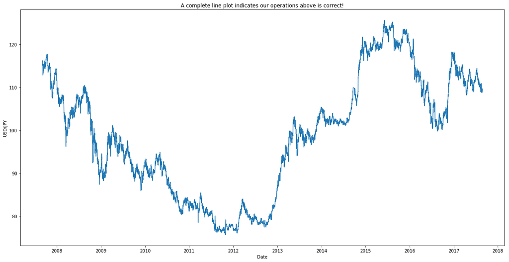

```python
plt.figure(figsize=(20,10))
plt.plot_date(final_mktdata[:]['datetime'],final_mktdata[:]['close'],fmt='-')
plt.xlabel('Date')
plt.ylabel('USD/JPY')
plt.title('A complete line plot indicates our operations above is correct!')
plt.show()
```

# II. Then we scrap the weekly CFTC Futures Holding Report of the currency JPY from the Internet with modules of requests and Beautifulsoup, we choose 38 items from the weekly report.

## The website we scraped doesn't ban scrapping. And we set a 0.5s seperation between each loop to avoid too much pressure on the Server.

## We have also set a automatically retry mechanism to avoid the codes from shutting down because of website connection problem.

```python
def get_new_weeks(weeks):
    new_weeks = []
    for w in weeks:
        d1,d2 = w
        new_w = get_range_days(d1,d2)
        new_weeks.append(new_w)
    return new_weeks

def get_range_days(begind,endd):
    dates = []
    d1 = datetime.datetime.strptime(begind, "%Y%m%d")
    d2 = datetime.datetime.strptime(endd, "%Y%m%d")
    date = d1
    while date <= d2:
        dates.append(date)
        date = date+datetime.timedelta(days=1)
    dates = [str(d)[:10].replace('-','') for d in dates]
    return dates

def get_daily_cftc_data(n,in_date,total,start):
    view_perc_bar(n+1,total,start)
    date = str(in_date)[:4]+'-'+str(in_date)[4:6]+'-'+str(in_date)[6:]
    page = 'http://service.99qh.com/cftc/GetData.ashx?code=JAPANESE%20YEN%20-%20CHICAGO%20MERCANTILE%20EXCHANGE&date={}'.format(date)
    get = False
    num = 1
    while get==False or num>20:
        try:
            req = requests.get(page,timeout=10)
            get = True
        except:
            sys.stdout.write('\r')
            print('Time out for {}. Time out times: {}. Will try again!'.format(in_date,num))
            num+=1
    if num>20:
        sys.stdout.write('\r')
        print("Have tried and failed so many times for the day's data, so we give up this day.")
    soup = BeautifulSoup(req.text,'lxml')
    contents = [x.replace(',','') for x in soup.get_text().split('@')]
    df = contents[:10]+contents[30:50]+contents[-29:-21]
    df = pd.DataFrame([in_date]+df).T
    df.columns = ['until_date','total','fund_l','fund_s','fund_hedge','merch_l','merch_s','reported_l','reported_s','unrep_l','unrep_s',
                 'd_total','d_fund_l','d_fund_s','d_fund_h','d_merch_l','d_merch_s','d_rep_l','d_rep_s','d_unrep_l','d_unrep_s',
                 'total_perc','fund_l_perc','fund_s_perc','fund_hedge_perc','merch_l_perc','merch_s_perc','reported_l_perc','reported_s_perc','unrep_l_perc','unrep_s_perc',
                 '4T_fund_l_perc','4T_fund_s_perc','8T_fund_l_perc','8T_fund_s_perc','4N_fund_l_perc','4N_fund_s_perc','8N_fund_l_perc','8N_fund_s_perc']
    time.sleep(0.5)
    return df
def get_cftc_data(weeks):
    complete_weeks = get_new_weeks(weeks)
    cftc_days = [x[2] for x in complete_weeks]
    n,total,start = 0,len(cftc_days),time.time()
    print('Start scrapping cftc_data! Totally {} days to scrap'.format(total))
    cftc_dfs = [get_daily_cftc_data(n,d,total,start) for n,d in enumerate(cftc_days)]
    cftc_final = pd.concat(cftc_dfs)
    print('\ncftc_data finished! data shape is {}'.format(cftc_final.shape))
    return cftc_final
```

```python
cftc_data = get_cftc_data(weeks)
cftc_data.head()

# If you faced problems when using scrapping codes above, you can get the cftc_data from data.h5 which is saved before.
# cftc_data = pd.read_hdf('data.h5',key='cftc_data')
```

[output not shown]

|  | until_date | total | fund_l | fund_s | fund_hedge | merch_l | merch_s | reported_l | reported_s | unrep_l | ... | unrep_l_perc | unrep_s_perc | 4T_fund_l_perc | 4T_fund_s_perc | 8T_fund_l_perc | 8T_fund_s_perc | 4N_fund_l_perc | 4N_fund_s_perc | 8N_fund_l_perc | 8N_fund_s_perc |
| --- | --- | --- | --- | --- | --- | --- | --- | --- | --- | --- | --- | --- | --- | --- | --- | --- | --- | --- | --- | --- | --- |
| 0 | 20070904 | 269834 | 58339 | 65392 | 2003 | 175469 | 178832 | 235811 | 246227 | 34023 | ... | 12.6 | 8.7 | 50.0 | 53.0 | 62.0 | 67.0 | 50.0 | 51.0 | 62.0 | 65.0 |
| 0 | 20070911 | 299538 | 62733 | 57148 | 1205 | 195252 | 214810 | 259190 | 273163 | 40348 | ... | 13.5 | 8.8 | 50.0 | 50.0 | 60.0 | 65.0 | 45.0 | 48.0 | 55.0 | 60.0 |
| 0 | 20070918 | 168189 | 41534 | 62601 | 1078 | 93739 | 84116 | 136351 | 147795 | 31838 | ... | 18.9 | 12.1 | 37.0 | 46.0 | 49.0 | 62.0 | 37.0 | 46.0 | 49.0 | 62.0 |
| 0 | 20070925 | 171770 | 46051 | 48500 | 1236 | 91652 | 101925 | 138939 | 151661 | 32831 | ... | 19.1 | 11.7 | 38.0 | 46.0 | 50.0 | 61.0 | 38.0 | 46.0 | 49.0 | 60.0 |
| 0 | 20071002 | 197060 | 35521 | 63590 | 1139 | 127380 | 109662 | 164040 | 174391 | 33020 | ... | 16.8 | 11.5 | 51.0 | 48.0 | 60.0 | 62.0 | 50.0 | 48.0 | 60.0 | 62.0 |

5 rows × 39 columns

# III. Then we get the market data of two stock indexes: S&P 500 and Nikkei 225 with a module named pandas_datareader. We use the function it provides to scrap daily market data from Yahoo Finance. We use the 2 indexes return every day as two inputs for our model.

### BTW, because of Yahoo Finance's policy, the requiring frequency is limited in a fixed priod, so if you run the codes several times in a short period it may fail. At that time, please wait several minutes and run it again.

```python
def get_index_data(input_df):
    print('idx_data scrapping start!')
    dates = input_df['date'].tolist()
    start =  dates[0]
    end = dates[-1]
    sp500 = web.DataReader("^GSPC", 'yahoo',start, end)
    nl225 =  web.DataReader("^N225", 'yahoo', start, end)
    sp500.reset_index(inplace=True)
    nl225.reset_index(inplace=True)
    nl = nl225[['Date']]
    sp = sp500[['Date']]
    nl['return'] = nl225['Adj Close']/nl225['Adj Close'].shift(1)-1
    sp['return'] = sp500['Adj Close']/sp500['Adj Close'].shift(1)-1
    nl.columns = ['date','nl_r']
    sp.columns = ['date','sp_r']
    dff = pd.merge(nl,sp,how='outer',on='date')
    dff = dff[1:].fillna(0).reset_index(drop=True)
    dff['date'] = dff['date'].apply(lambda x:str(x)[:10].replace('-',''))
    print('idx_data scrapping finished! data length is {}'.format(len(dff)))
    return dff
```

```python
idx_data = get_index_data(final_mktdata)
idx_data.head()


# If you faced problems when requesting index data, you can get the idx_data from data.h5 which is saved before.
# idx_data=pd.read_hdf('data.h5',key='idx_data')
```

```
idx_data scrapping start!
idx_data scrapping finished! data length is 2594
```

|  | date | nl_r | sp_r |
| --- | --- | --- | --- |
| 0 | 20070905 | -0.015957 | -0.011501 |
| 1 | 20070906 | 0.006099 | 0.004252 |
| 2 | 20070907 | -0.008294 | -0.016908 |
| 3 | 20070910 | -0.022155 | -0.001273 |
| 4 | 20070911 | 0.007149 | 0.013632 |

# IV. We calculate a lot indicators according to our Forex mktdata with the help of talib module.

### 目前包含的指标有SMA,EMA,STOCH,ADX,ATR,STD,SAR,WILLR,STOCHRSI,RSI,TYPPRICE， 但是未来应该还会增加

```python
def get_indicators(new_df):
    print('Start calculating indicators')
    O = np.array(new_df['open'])
    H = np.array(new_df['high'])
    L = np.array(new_df['low'])
    C = np.array(new_df['close'])
    indi_df = new_df[['datetime','close','open','high','low']]
    indi_df['adx'] = talib.ADX(H,L,C,14)
    indi_df['sma'] = talib.SMA(C,10)
    indi_df['ema'] = talib.EMA(C,10)
    indi_df['sar'] = talib.SAR(H,L)
    indi_df['stoch_k'],indi_df['stoch_d'] = talib.STOCH(H,L,C)
    indi_df['atr'] = talib.ATR(H,L,C)
    indi_df['std'] = talib.STDDEV(C)
    indi_df['willr'] = talib.WILLR(H,L,C)
    indi_df['stochrsi_k'],indi_df['stochrsi_d'] = talib.STOCHRSI(C)
    indi_df['rsi'] = talib.RSI(C)
    indi_df['typprice'] = talib.TYPPRICE(H,L,C)
    indi_df = indi_df.dropna().reset_index(drop=True)
    print('indi_data calculating finished! length is {}'.format(len(indi_df)))
    return indi_df
```

```python
indi_data = get_indicators(final_mktdata)
indi_data.head()
```

```
Start calculating indicators
indi_data calculating finished! length is 15201
```

|  | datetime | close | open | high | low | adx | sma | ema | sar | stoch_k | stoch_d | atr | std | willr | stochrsi_k | stochrsi_d | rsi | typprice |
| --- | --- | --- | --- | --- | --- | --- | --- | --- | --- | --- | --- | --- | --- | --- | --- | --- | --- | --- |
| 0 | 2007-09-11 04:00:00 | 113.56 | 113.58 | 113.88 | 113.40 | 58.652476 | 113.392 | 113.689574 | 114.332096 | 48.315412 | 55.895599 | 0.495365 | 0.070541 | -67.441860 | 95.596130 | 93.465735 | 30.913463 | 113.613333 |
| 1 | 2007-09-11 08:00:00 | 113.81 | 113.56 | 113.85 | 113.45 | 56.974956 | 113.437 | 113.711470 | 114.226970 | 60.489642 | 55.472935 | 0.488553 | 0.101390 | -54.612546 | 100.000000 | 98.532043 | 36.857622 | 113.703333 |
| 2 | 2007-09-11 12:00:00 | 113.96 | 113.81 | 114.13 | 113.65 | 54.399438 | 113.548 | 113.756657 | 112.580000 | 70.267420 | 59.690825 | 0.487942 | 0.170364 | -49.077491 | 100.000000 | 98.532043 | 40.183121 | 113.913333 |
| 3 | 2007-09-11 16:00:00 | 114.27 | 113.95 | 114.35 | 113.91 | 51.300541 | 113.653 | 113.849992 | 112.611000 | 85.682625 | 72.146562 | 0.484518 | 0.263105 | -37.638376 | 100.000000 | 100.000000 | 46.459036 | 114.176667 |
| 4 | 2007-09-11 20:00:00 | 114.09 | 114.26 | 114.35 | 114.09 | 48.422993 | 113.729 | 113.893630 | 112.680560 | 80.514620 | 78.821555 | 0.468481 | 0.242107 | -14.689266 | 81.600107 | 93.866702 | 43.598667 | 114.176667 |

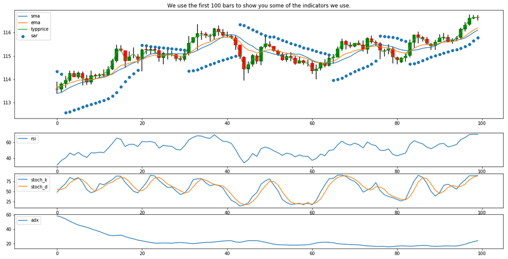

```python
def plot_indicators(in_data,length=100):
    data = in_data[:length]
    X = data.index
    fig = plt.figure(figsize=(20,10))
    ax1 = fig.add_subplot(211)
    ax2 = fig.add_subplot(614)
    ax3 = fig.add_subplot(615)
    ax4 = fig.add_subplot(616)
    ax1.set_title('We use the first {} bars to show you some of the indicators we use.'.format(length))
    data['change'] = data['close']-data['open']
    data_up = data[data['change']>=0]
    data_down = data[data['change']<0]
    ax1.bar(data_up.index,data_up['change'],bottom=data_up['open'],color='green')
    ax1.bar(data_down.index,data_down['change'],bottom=data_down['open'],color='red')
    for i,h,o,l,c in zip(data_up.index,data_up['high'],data_up['open'],data_up['low'],data_up['close']):
        ax1.plot([i,i],[l,o],color='k'); ax1.plot([i,i],[c,h],color='k')
    for i,h,o,l,c in zip(data_down.index,data_down['high'],data_down['open'],data_down['low'],data_down['close']):
        ax1.plot([i,i],[l,c],color='k'); ax1.plot([i,i],[o,h],color='k')
    #ax1.plot(X,data['close'],'-')
    sma, = ax1.plot(X,data['sma'],'-')
    ema, = ax1.plot(X,data['ema'],'-')
    typ, = ax1.plot(X,data['typprice'],'-')
    sar = ax1.scatter(X,data['sar'])
    ax2.plot(X,data['rsi'],'-')
    ax3.plot(X,data['stoch_k'],'-')
    ax3.plot(X,data['stoch_d'],'-')
    ax4.plot(X,data['adx'],'-')
    ax1.set_xlim(-10,105); ax2.set_xlim(-10,105); ax3.set_xlim(-10,105); ax4.set_xlim(-10,105)

    ax2.legend(loc='upper left');ax3.legend(loc='upper left');ax4.legend(loc='upper left')
    need_legend = ax1.legend(handles=[sma,ema,typ,sar], loc='upper left')
    ax1.add_artist(need_legend)
    plt.show()
plot_indicators(indi_data)
```

# V.Then we merge the indi_data,cftc_data,mkt_data,idx_data together to get our final_df.

### It really takes much time to finish this process because we try our best to avoid "future data". For example:

### 1.for cftc_df, the original date is "until date", not "publish date", the "publish date" is on Saturday, and is 4 day later then the "until date". So we merge cftc_data with the mktdata the next week.

```python
def combine_cftc_and_mkdata(cftc_final,mkdata,weeks=weeks):
    cftc_final.reset_index(drop=True,inplace=True)
    final = []
    for i,w in zip(range(len(cftc_final)-1),weeks[1:]):
        d1,d2= w
        cftc_temp = cftc_final.iloc[[i],:]
        cftc = pd.concat([cftc_temp]*6)
        days = get_range_days(d1,d2)
        cftc['until_date'] = days
        final.append(cftc)
    cftc_df = pd.concat(final)
    cftc_df.columns = ['date']+cftc_final.columns.tolist()[1:]
    final = pd.merge(mkdata,cftc_df,how='left',on='date').dropna()
    print('cftc merge finished!')
    return final

def combine_idx_and_mktdata(idx_df,mkt_df):
    first_d = idx_df['date'][0]
    mkt_df = mkt_df[mkt_df['date']>=first_d]
    dates = sorted(mkt_df['date'].unique())
    final = []
    n,total,start,final = 0,len(dates)-1,time.time(),[]
    for d1,d2 in zip(dates[:-1],dates[1:]):
        n+=1;  view_perc_bar(n,total,start)
        temp = mkt_df[ ((mkt_df['date']==d1)&(mkt_df['hour']>='6'))|((mkt_df['date']==d2)&(mkt_df['hour']<'6')) ]
        idx_temp = idx_df[idx_df['date']==d1]
        _,nl,_ = idx_temp.values[0] if len(idx_temp)>0 else (0,0,0)
        temp['nl_r'] = nl
        final.append(temp)
    mkt_df = pd.concat(final)
    sys.stdout.write('\r')
    print('Nikkei_225_r merge finished!')
    n,total,start,final = 0,len(dates)-1,time.time(),[]
    for d1,d2 in zip(dates[:-1],dates[1:]):
        n+=1; view_perc_bar(n,total,start)
        temp = mkt_df[ ((mkt_df['date']==d1)&(mkt_df['hour']>='21'))|((mkt_df['date']==d2)&(mkt_df['hour']<'21')) ]
        idx_temp = idx_df[idx_df['date']==d1]
        _,_,sp = idx_temp.values[0] if len(idx_temp)>0 else (0,0,0)
        temp['sp_r'] = sp
        final.append(temp)
    mkt_df = pd.concat(final)
    sys.stdout.write('\r')
    print('S&P500_r merge finished!')
    return mkt_df
def combine_indi_and_mktdata(indi_df,mkt_data):
    final = pd.merge(mkt_data,indi_df,how='left',on=['datetime','close','open','high','low'])
    final.dropna(inplace=True)
    print('indicator merge finished')
    return final
```

```python
mid_data1 = combine_cftc_and_mkdata(cftc_data,final_mktdata)
mid_data2 = combine_idx_and_mktdata(idx_data,mid_data1)
final_data = combine_indi_and_mktdata(indi_data,mid_data2)
print('The shape of final_data: {}'.format(final_data.shape))
final_data.head()
```

```
cftc merge finished!
Nikkei_225_r merge finished!
S&P500_r merge finished!
indicator merge finished
The shape of final_data: (15201, 70)
```

|  | symbol | date | time | open | high | low | close | datetime | wkd | day | ... | sar | stoch_k | stoch_d | atr | std | willr | stochrsi_k | stochrsi_d | rsi | typprice |
| --- | --- | --- | --- | --- | --- | --- | --- | --- | --- | --- | --- | --- | --- | --- | --- | --- | --- | --- | --- | --- | --- |
| 1 | USDJPY | 20070911 | 0400 | 113.58 | 113.88 | 113.40 | 113.56 | 2007-09-11 04:00:00 | 2 | 11 | ... | 114.332096 | 48.315412 | 55.895599 | 0.495365 | 0.070541 | -67.441860 | 95.596130 | 93.465735 | 30.913463 | 113.613333 |
| 2 | USDJPY | 20070911 | 0800 | 113.56 | 113.85 | 113.45 | 113.81 | 2007-09-11 08:00:00 | 2 | 11 | ... | 114.226970 | 60.489642 | 55.472935 | 0.488553 | 0.101390 | -54.612546 | 100.000000 | 98.532043 | 36.857622 | 113.703333 |
| 3 | USDJPY | 20070911 | 1200 | 113.81 | 114.13 | 113.65 | 113.96 | 2007-09-11 12:00:00 | 2 | 11 | ... | 112.580000 | 70.267420 | 59.690825 | 0.487942 | 0.170364 | -49.077491 | 100.000000 | 98.532043 | 40.183121 | 113.913333 |
| 4 | USDJPY | 20070911 | 1600 | 113.95 | 114.35 | 113.91 | 114.27 | 2007-09-11 16:00:00 | 2 | 11 | ... | 112.611000 | 85.682625 | 72.146562 | 0.484518 | 0.263105 | -37.638376 | 100.000000 | 100.000000 | 46.459036 | 114.176667 |
| 5 | USDJPY | 20070911 | 2000 | 114.26 | 114.35 | 114.09 | 114.09 | 2007-09-11 20:00:00 | 2 | 11 | ... | 112.680560 | 80.514620 | 78.821555 | 0.468481 | 0.242107 | -14.689266 | 81.600107 | 93.866702 | 43.598667 | 114.176667 |

5 rows × 70 columns

# VI. Delete some useless columns

```python
def delete_useless_columns(input_df):
    df = input_df.copy()
    df.sort_values('datetime',inplace=True);df.reset_index(drop=True,inplace=True)
    del df['datetime'],df['date'],df['time'],df['symbol'],df['minute'],df['day'],df['month'],df['total_perc']
    print('The shape of final_data after deleting: {}'.format(df.shape))
    return df
```

```python
final_df = delete_useless_columns(final_data)
final_df.head()
```

```
The shape of final_data after deleting: (15201, 62)
```

|  | open | high | low | close | wkd | hour | r | lag_r | next_r | lag_r_ma10 | ... | sar | stoch_k | stoch_d | atr | std | willr | stochrsi_k | stochrsi_d | rsi | typprice |
| --- | --- | --- | --- | --- | --- | --- | --- | --- | --- | --- | --- | --- | --- | --- | --- | --- | --- | --- | --- | --- | --- |
| 0 | 113.58 | 113.88 | 113.40 | 113.56 | 2 | 04 | -0.000176 | 0.000529 | 0.002201 | -0.000348 | ... | 114.332096 | 48.315412 | 55.895599 | 0.495365 | 0.070541 | -67.441860 | 95.596130 | 93.465735 | 30.913463 | 113.613333 |
| 1 | 113.56 | 113.85 | 113.45 | 113.81 | 2 | 08 | 0.002201 | -0.000176 | 0.001318 | 0.000398 | ... | 114.226970 | 60.489642 | 55.472935 | 0.488553 | 0.101390 | -54.612546 | 100.000000 | 98.532043 | 36.857622 | 113.703333 |
| 2 | 113.81 | 114.13 | 113.65 | 113.96 | 2 | 12 | 0.001318 | 0.002201 | 0.002720 | 0.000980 | ... | 112.580000 | 70.267420 | 59.690825 | 0.487942 | 0.170364 | -49.077491 | 100.000000 | 98.532043 | 40.183121 | 113.913333 |
| 3 | 113.95 | 114.35 | 113.91 | 114.27 | 2 | 16 | 0.002720 | 0.001318 | -0.001575 | 0.000924 | ... | 112.611000 | 85.682625 | 72.146562 | 0.484518 | 0.263105 | -37.638376 | 100.000000 | 100.000000 | 46.459036 | 114.176667 |
| 4 | 114.26 | 114.35 | 114.09 | 114.09 | 2 | 20 | -0.001575 | 0.002720 | 0.001665 | 0.000669 | ... | 112.680560 | 80.514620 | 78.821555 | 0.468481 | 0.242107 | -14.689266 | 81.600107 | 93.866702 | 43.598667 | 114.176667 |

5 rows × 62 columns

# VII. Lbel, train and Test:

### we change the "thresh" parameter of the function "add_label" little by little and record the test performance of our models which is trained on train and tested on test.

### 1.Add label according to the relationship of thresh and next_r(the return of the next bar)

#### label = 1 <------- next_r > thresh

#### label = 0 <------- -thresh < next_r < thresh

#### label = -1 <------- next_r < -thresh

### 2.Split data into train(first 80%) and test(last 20%)

### 3. Train models with the train data and test on the test data

```python
def to_label(i,thresh=0):
    if i<0-thresh:
        l = -1
    elif i>0+thresh:
        l = 1
    else:
        l = 0
    return l

def add_label(input_df,thresh=0):
    df = input_df.copy()
    df['label'] = df['next_r'].apply(lambda x:to_label(x,thresh))
    return df

def split_data(input_df,perc=0.8):
    df = input_df.copy()
    df.reset_index(drop=True,inplace=True)
    length = len(df);  train_length = int(length*perc)
    train,test= df[:train_length],df[train_length:]
    train_X = train[[i for i in train.columns if i not in ['next_r','label']]]
    test_X = test[[i for i in train.columns if i not in ['next_r','label']]]
    train_Y = train[['next_r','label']]
    test_Y = test[['next_r','label']]
    return train_X,train_Y,test_X,test_Y
```

```python
# chance_perc, trades, Accuracy, Upaccuracy,Downaccuracy,  longaccuracy,shortaccuracy, Average_ret/trade,
def max_drawdown(in_returns):
    returns=[1]
    for i in in_returns:
        returns.append(returns[-1]+i)
    max_returns = np.maximum.accumulate(returns)
    draw = returns / max_returns
    max_draw = np.minimum.accumulate(draw)
    draw_series = (1 - max_draw)
    return draw_series

def get_test_results(model,train_X,train_Y,test_X,test_Y):
    result = model.fit(train_X,train_Y[['label']])
    test_Y['pred_label'] = result.predict(test_X)
    up_df = test_Y[test_Y['label']==1]
    down_df = test_Y[test_Y['label']==-1]
    buy_df = test_Y[test_Y['pred_label']==1]
    sell_df = test_Y[test_Y['pred_label']==-1]
    total = len(test_Y); long_total = len(buy_df); short_total = len(sell_df); up_total = len(up_df); down_total = len(down_df)
    chances = (len(up_df)+len(down_df));trades = (len(buy_df)+len(sell_df))
    right_pred = len(test_Y[test_Y['pred_label']==test_Y['label']]);
    right_up = len(up_df[up_df['pred_label']==up_df['label']]); right_down = len(down_df[down_df['pred_label']==down_df['label']])
    right_long = len(buy_df[buy_df['pred_label']==buy_df['label']]); right_short = len(sell_df[sell_df['pred_label']==sell_df['label']])
    long_return = buy_df['next_r'].sum(); short_return = ((-1)*sell_df['next_r']).sum()
    results = [ chances/total , trades , right_pred/total, right_up/up_total if up_total>0 else 0,right_down/down_total if down_total>0 else 0,
                 right_long/long_total if long_total>0 else 0, right_short/short_total if short_total>0 else 0,
                (long_return+short_return)/(long_total+short_total)*100 if (long_total+short_total)>0 else 0,
                 long_return/long_total*100 if long_total>0 else 0, short_return/short_total*100 if short_total>0 else 0,
                 max_drawdown(test_Y['next_r']*test_Y['pred_label']).max()*100,(test_Y['next_r']*test_Y['pred_label']).sum()*100]
    results = [round(x,3) for x in results]
    weights = result.feature_importances_ if type(model)==RandomForestClassifier else abs(result.coef_).sum(axis=0)
    return results,weights
```

```python
def get_result_panel(df,model,threshes):
    items = ['Not_0_Perc','Trades','Accuracy','UpAccu','DownAccu','LongAccu','ShortAccu','AvgR(%)/trade','AvgR(%)/Long','AvgR(%)/Short','MAXDD(%)','Cum_R(%)']
    results = []; t_weights = []
    n,total,start = 0,len(threshes),time.time()
    for th in threshes:
        ddf= add_label(df,th)
        train_X,train_Y,test_X,test_Y = split_data(ddf)
        result,weights = get_test_results(model,train_X,train_Y,test_X,test_Y)
        n+=1; view_perc_bar(n,total,start)
        t_weights.append(weights)
        results.append(result)
    sys.stdout.write('\r'); sys.stdout.flush()
    weight_df = pd.DataFrame(t_weights,columns=train_X.columns)
    weight_final = pd.concat([weight_df.mean(),weight_df.std(),weight_df.mean()/weight_df.std()],axis=1).fillna(0)
    weight_final.columns=['mean','std','R']
    final = pd.DataFrame(results,columns = items)
    final['threshes'] = threshes; final.set_index('threshes',inplace=True)
    result = {str(type(model)):final}
    return result,weight_final
```

```python
def plot_the_result(result,weight_df,pie=False,k=9):
    model_type = list(result)[0];   result = result[model_type]
    returns = result['Cum_R(%)']; threshes = result.index;
    fig = plt.figure(figsize=(15,15))
    ax1 = fig.add_subplot(211); ax2 = ax1.twinx()
    maxdd = ax1.fill_between(np.array(threshes),np.array((-1)*result['MAXDD(%)']),y2=0,color='lightblue',alpha=.3)
    ax1.set_ylabel('Cum_R(%) & MAXDD(%)'); ax1.set_xlabel("Threshes")
    ax1.set_title("The result of the model: {}".format(model_type),color='b')
    ax1.bar(threshes,[r if r>0 else 0 for r in returns],width=0.0001,color='pink',align='center')
    ax1.bar(threshes,[r if r<0 else 0 for r in returns],width=0.0001,color='lightgreen',align='center')
    ax2.set_ylim([0,1]); ax1.set_xlim(threshes[0]-0.0002,threshes[-1]+0.0002)
    ax2.set_ylabel("Accuracy & Not_0_Perc")
    acc, =ax2.plot(threshes,result['Accuracy']);in_perc, = ax2.plot(threshes,result['Not_0_Perc']);
    ax1.legend((maxdd,acc,in_perc), ('MAXDD','Accuracy','Not_0_Perc',),loc='upper right'); ax1.grid()
    if model_type=="<class 'sklearn.ensemble.forest.RandomForestClassifier'>" and pie:
        ax3 = fig.add_subplot(223); ax4 = fig.add_subplot(224)
        weight_df.sort_values('mean',ascending=False,inplace=True)
        sizes = list(weight_df['mean'][:k])+[sum(weight_df['mean'][k:])]
        labels = weight_df.index.tolist()[:k]+['others']
        ax3.pie([(s/np.mean(sizes)) for s in sizes],labels=labels, autopct='%1.1f%%',shadow=True, startangle=90,labeldistance=1.05,pctdistance=0.8)
        ax3.set_title("The {} variables with the biggest <Importance Mean>".format(k),color='b')
        weight_df.sort_values('R',ascending=False,inplace=True)
        sizes = list(weight_df['R'][:k])+[sum(weight_df['R'][k:])]
        labels = weight_df.index.tolist()[:k]+['others']
        ax4.pie([(s/np.mean(sizes)) for s in sizes],labels=labels, autopct='%1.1f%%',shadow=True, startangle=90,labeldistance=1.05,pctdistance=0.8)
        ax4.set_title("The {} variables with the biggest <Importance R>".format(k),color='b')
    plt.show()
```

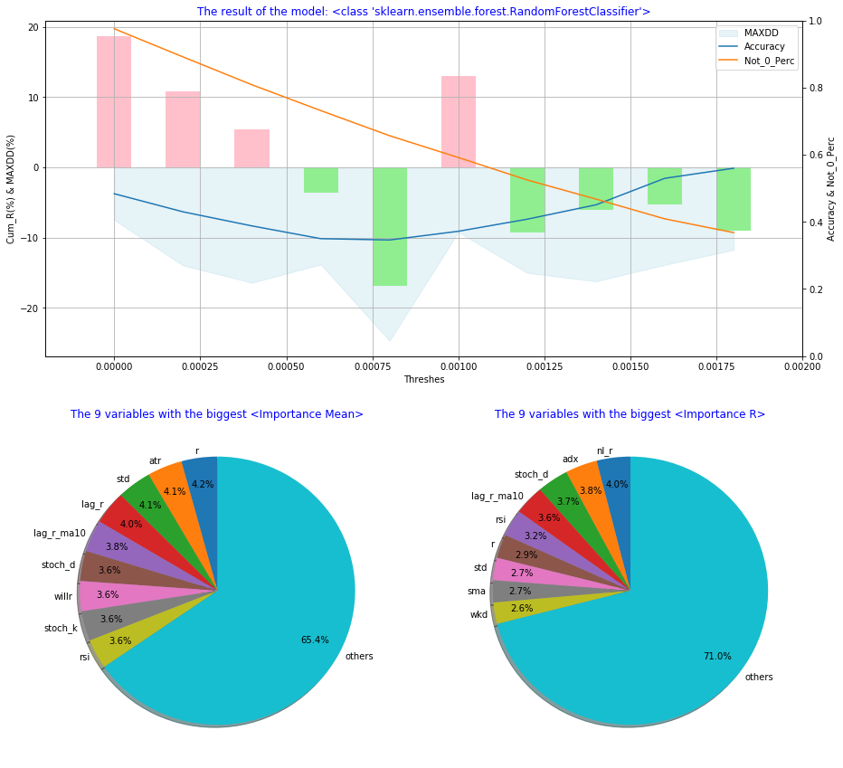

| threshes | Not_0_Perc | Trades | Accuracy | UpAccu | DownAccu | LongAccu | ShortAccu | AvgR(%)/trade | AvgR(%)/Long | AvgR(%)/Short | MAXDD(%) | Cum_R(%) |
| --- | --- | --- | --- | --- | --- | --- | --- | --- | --- | --- | --- | --- |
| 0.0000 | 0.976 | 3041 | 0.484 | 0.434 | 0.561 | 0.499 | 0.473 | 0.006 | 0.004 | 0.008 | 7.486 | 18.730 |
| 0.0002 | 0.892 | 2967 | 0.430 | 0.385 | 0.585 | 0.468 | 0.423 | 0.004 | 0.001 | 0.005 | 13.977 | 10.776 |
| 0.0004 | 0.809 | 2734 | 0.388 | 0.420 | 0.495 | 0.438 | 0.388 | 0.002 | 0.001 | 0.002 | 16.434 | 5.359 |
| 0.0006 | 0.732 | 2259 | 0.350 | 0.319 | 0.427 | 0.390 | 0.347 | -0.002 | -0.002 | -0.001 | 13.826 | -3.649 |
| 0.0008 | 0.657 | 2079 | 0.346 | 0.307 | 0.380 | 0.343 | 0.318 | -0.008 | -0.014 | -0.003 | 24.703 | -16.826 |
| 0.0010 | 0.592 | 1719 | 0.372 | 0.255 | 0.350 | 0.325 | 0.308 | 0.008 | 0.011 | 0.005 | 9.218 | 12.975 |
| 0.0012 | 0.525 | 1333 | 0.408 | 0.191 | 0.272 | 0.302 | 0.261 | -0.007 | -0.011 | -0.005 | 15.029 | -9.275 |
| 0.0014 | 0.468 | 1024 | 0.451 | 0.193 | 0.169 | 0.268 | 0.235 | -0.006 | -0.001 | -0.011 | 16.236 | -6.096 |
| 0.0016 | 0.409 | 697 | 0.530 | 0.114 | 0.151 | 0.267 | 0.218 | -0.008 | 0.002 | -0.013 | 13.887 | -5.272 |
| 0.0018 | 0.368 | 616 | 0.560 | 0.103 | 0.129 | 0.226 | 0.201 | -0.015 | 0.005 | -0.028 | 11.758 | -9.055 |

```python
threshes = np.arange(0,0.002,0.0002)
result_final,weight_final = get_result_panel(final_df,RandomForestClassifier(),threshes)
plot_the_result(result_final,weight_final,True)
list(result_final.values())[0]
```

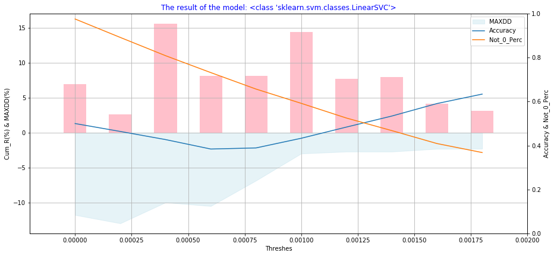

| threshes | Not_0_Perc | Trades | Accuracy | UpAccu | DownAccu | LongAccu | ShortAccu | AvgR(%)/trade | AvgR(%)/Long | AvgR(%)/Short | MAXDD(%) | Cum_R(%) |
| --- | --- | --- | --- | --- | --- | --- | --- | --- | --- | --- | --- | --- |
| 0.0000 | 0.976 | 3041 | 0.500 | 0.838 | 0.167 | 0.503 | 0.484 | 0.002 | -0.000 | 0.015 | 11.798 | 6.941 |
| 0.0002 | 0.892 | 3041 | 0.464 | 0.799 | 0.220 | 0.468 | 0.452 | 0.001 | -0.001 | 0.009 | 12.997 | 2.622 |
| 0.0004 | 0.809 | 2986 | 0.427 | 0.795 | 0.220 | 0.433 | 0.415 | 0.005 | 0.002 | 0.019 | 10.001 | 15.601 |
| 0.0006 | 0.732 | 1765 | 0.384 | 0.516 | 0.135 | 0.426 | 0.400 | 0.005 | 0.005 | 0.003 | 10.522 | 8.114 |
| 0.0008 | 0.657 | 1038 | 0.389 | 0.312 | 0.094 | 0.415 | 0.347 | 0.008 | 0.010 | 0.003 | 6.874 | 8.097 |
| 0.0010 | 0.592 | 508 | 0.433 | 0.181 | 0.053 | 0.438 | 0.362 | 0.028 | 0.041 | -0.008 | 3.000 | 14.381 |
| 0.0012 | 0.525 | 280 | 0.484 | 0.116 | 0.022 | 0.427 | 0.283 | 0.027 | 0.052 | -0.062 | 2.721 | 7.678 |
| 0.0014 | 0.468 | 162 | 0.534 | 0.083 | 0.004 | 0.399 | 0.214 | 0.049 | 0.063 | -0.093 | 2.723 | 8.005 |
| 0.0016 | 0.409 | 74 | 0.591 | 0.041 | 0.000 | 0.338 | 0.000 | 0.057 | 0.057 | 0.000 | 2.326 | 4.182 |
| 0.0018 | 0.368 | 28 | 0.634 | 0.022 | 0.000 | 0.429 | 0.000 | 0.110 | 0.110 | 0.000 | 2.307 | 3.088 |

```python
threshes = np.arange(0,0.002,0.0002)
result_final,weight_final = get_result_panel(final_df,LinearSVC(penalty='l1',dual=False),threshes)
plot_the_result(result_final,weight_final,True)
list(result_final.values())[0]
```

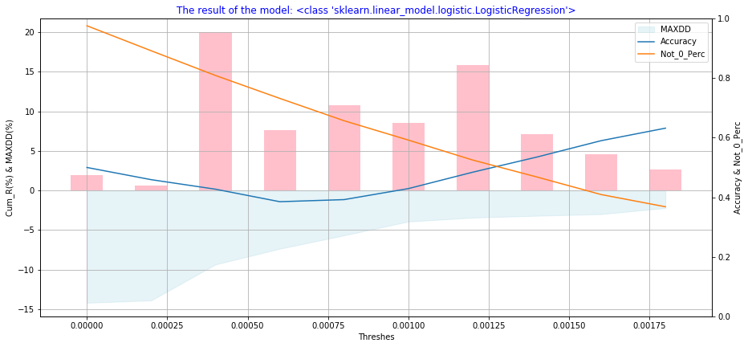

| threshes | Not_0_Perc | Trades | Accuracy | UpAccu | DownAccu | LongAccu | ShortAccu | AvgR(%)/trade | AvgR(%)/Long | AvgR(%)/Short | MAXDD(%) | Cum_R(%) |
| --- | --- | --- | --- | --- | --- | --- | --- | --- | --- | --- | --- | --- |
| 0.0000 | 0.976 | 3041 | 0.500 | 0.830 | 0.177 | 0.504 | 0.480 | 0.001 | -0.001 | 0.010 | 14.182 | 1.995 |
| 0.0002 | 0.892 | 3041 | 0.459 | 0.799 | 0.207 | 0.464 | 0.439 | 0.000 | -0.002 | 0.007 | 13.882 | 0.647 |
| 0.0004 | 0.809 | 2992 | 0.427 | 0.808 | 0.206 | 0.432 | 0.412 | 0.007 | 0.003 | 0.023 | 9.343 | 20.007 |
| 0.0006 | 0.732 | 1914 | 0.385 | 0.551 | 0.143 | 0.415 | 0.407 | 0.004 | 0.002 | 0.011 | 7.358 | 7.628 |
| 0.0008 | 0.657 | 1175 | 0.392 | 0.357 | 0.107 | 0.411 | 0.376 | 0.009 | 0.010 | 0.007 | 5.669 | 10.823 |
| 0.0010 | 0.592 | 576 | 0.429 | 0.205 | 0.042 | 0.409 | 0.330 | 0.015 | 0.026 | -0.029 | 3.923 | 8.573 |
| 0.0012 | 0.525 | 362 | 0.484 | 0.163 | 0.020 | 0.422 | 0.327 | 0.044 | 0.057 | -0.038 | 3.430 | 15.870 |
| 0.0014 | 0.468 | 213 | 0.535 | 0.109 | 0.006 | 0.398 | 0.235 | 0.034 | 0.051 | -0.168 | 3.190 | 7.139 |
| 0.0016 | 0.409 | 123 | 0.590 | 0.069 | 0.000 | 0.344 | 0.000 | 0.037 | 0.039 | -0.111 | 2.986 | 4.589 |
| 0.0018 | 0.368 | 54 | 0.632 | 0.034 | 0.000 | 0.352 | 0.000 | 0.049 | 0.049 | 0.000 | 2.214 | 2.662 |

```python
threshes = np.arange(0,0.002,0.0002)
result_final,weight_final = get_result_panel(final_df,LogisticRegression(penalty='l1',n_jobs=-1),threshes)
plot_the_result(result_final,weight_final,True)
list(result_final.values())[0]
```

# Above are the results of the three models, details can be find in the Discussion and Analysis part of the research report.